# Ewing sarcoma RNA-seq

2026-03-19

### Introduction

This report presents a comprehensive differential gene expression analysis of Ewing Sarcoma cell lines. The study aims to characterize the transcriptomic shifts occurring upon the knockdown of the EWSR1-FLI1 fusion oncogene (shEF1 condition) compared to control samples (shCTR).

```r
# Library imports
library(tidyverse)
library(DESeq2)
library(EnsDb.Hsapiens.v86)
library(EnhancedVolcano)
library(dplyr)
library(ggplot2)
library(ggplotify)
library(pheatmap)
library(apeglm)
library(msigdbr)
library(ggpubr)
library(clusterProfiler)
library(enrichplot)
library(DT)

# Read and inspect the dataset

rse <- readRDS("EwS.rds")
cd <- as.data.frame(colData(rse))
colData(rse) <- colData(rse)[, c("sample", "run", "condition")] # select data for analysis
rse$condition <- factor(rse$condition) # change raw text to factor format
rse$condition <- relevel(rse$condition, ref = "shCTR") # assign the control factor explicitly
all(rownames(colData(rse)) == colnames(assay(rse))) # check if the metadata match count matrix
assay(rse)[1:5, 1:5] # check the genes designation

# make the gene names readable for annotation
rownames(rse) <- gsub(pattern = "\\..+", replacement = "", x = rownames(rse))
assay(rse)[1:5, 1:5]
all(assay(rse) == floor(assay(rse))) # check if counts are integers
```

### Setup and Data import

Before proceeding with the differential analysis, the dataset was validated:

- Sample IDs in the count matrix and metadata were cross-referenced for consistency.
- The control group (shCTR) was established as the reference level for all comparative analyses.
- Ensembl IDs were stripped of version suffixes to facilitate accurate mapping to gene symbols.
- The count matrix was verified to contain raw integers as required for the DESeq2 statistical model.

### QC and Normalization

#### PCA Plot

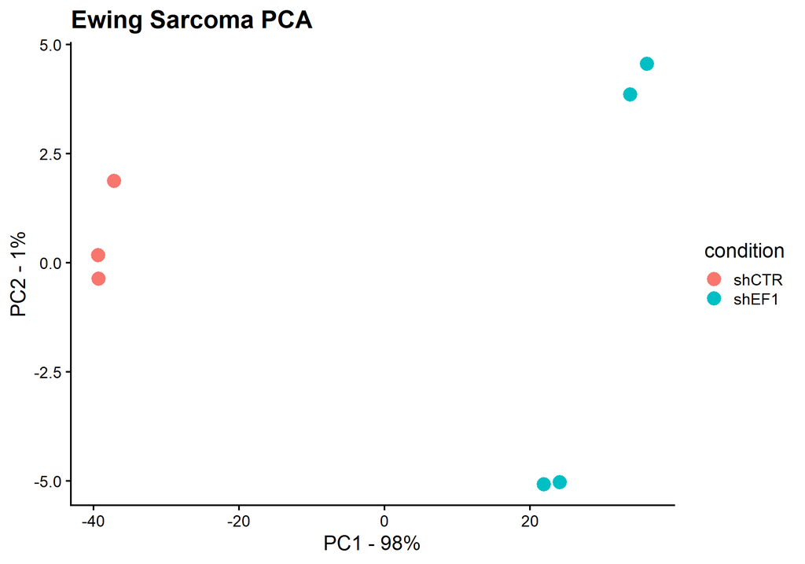

```r
# Normalization
dds <- DESeqDataSet(rse, design = ~condition)
keep <- rowSums(counts(dds)) >= 10
dds <- dds[keep, ]
vsd <- vst(dds, blind = FALSE)

# PCA
pcaData <- plotPCA(vsd, intgroup = "condition", returnData = TRUE)
percentVar <- round(100 * attr(pcaData, "percentVar"))

ggplot(pcaData, aes(x = PC1, y = PC2, color = condition, label = name)) +
  geom_point(size = 5) +
  xlab(paste0("PC1 - ", percentVar[1], "%")) +
  ylab(paste0("PC2 - ", percentVar[2], "%")) +
  theme_classic(base_size = 18) +
  ggtitle("Ewing Sarcoma PCA") +
  theme(plot.title = element_text(size = 22, face = "bold"))
```

Principal Component Analysis (PCA) of the variance-stabilized counts shows a clear separation between control (shCTR) and knockdown (shEF1) samples along the first principal component (PC1). PC1 and PC2 together account for 99% of the total variance, confirming that the experimental condition is the primary driver of transcriptional changes. Notably, the knockdown group exhibits a secondary split along PC2, dividing the four replicates into two distinct sub-groups, however PC2 explains only 1% of the data.

#### MA Plot

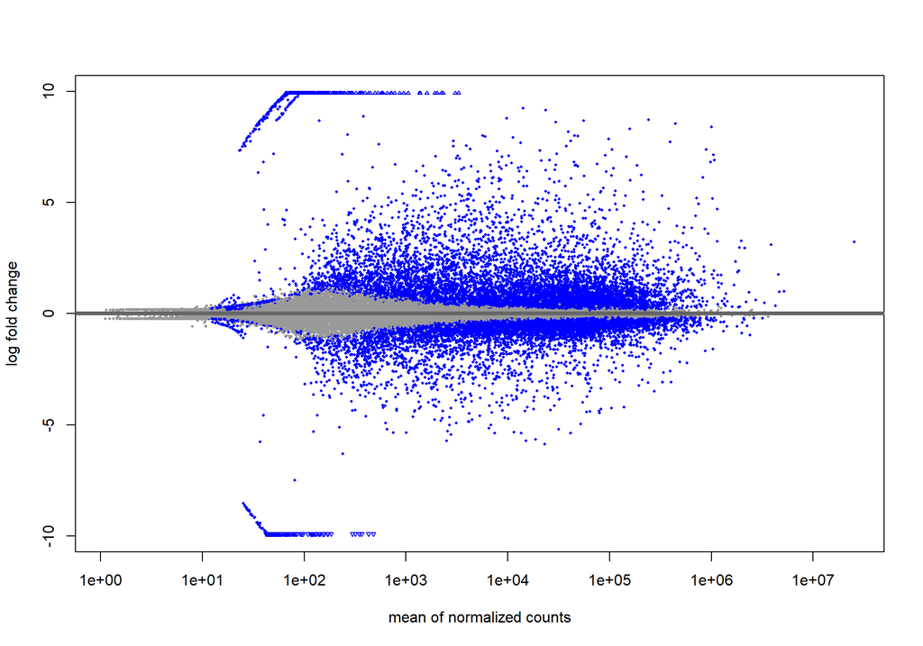

```r
dds <- DESeq(dds)
res <- results(dds, contrast = c("condition", "shEF1", "shCTR"))
resNorm <- lfcShrink(dds = dds, res = res, type = "apeglm", coef = 2)
plotMA(resNorm)
```

Initial exploratory data analysis, including PCA and MA plots, confirmed the high quality and consistency of the transcriptomic profiles.

Collectively, these QC metrics verify that the library preparation and sequencing procedures were successful, and the dataset is suitable for rigorous differential expression analysis.

### Differentially expressed genes

The primary objective of this analysis was to identify specific genes whose expression levels were significantly altered upon the suppression of the EWSR1-FLI1 fusion oncogene. Differential expression was modeled using the DESeq2 package.

#### Top 20 Significant DEGs

```r
# Global settings
p_adj_cut <- 0.01
lfc_cut <- 1
base_mean_cut <- 20
# Annotation
ens2sym <- AnnotationDbi::select(EnsDb.Hsapiens.v86,
  keys = keys(EnsDb.Hsapiens.v86),
  columns = c("SYMBOL")
)

resdf <- as.data.frame(resNorm) |>
  rownames_to_column() |>
  mutate(GENEID = gsub(rowname, pattern = "\\..+", replacement = "")) |>
  dplyr::select(-rowname) |>
  inner_join(y = ens2sym, by = "GENEID")

# Сreate significant genes list
sig_res <- resdf |>
  filter(padj < p_adj_cut & abs(log2FoldChange) >= lfc_cut & baseMean >= base_mean_cut)


# Get the top 20 DEGs
top_20_degs <- sig_res |>
  arrange(padj) |>
  head(20) |>
  dplyr::select(SYMBOL, GENEID, baseMean, log2FoldChange, padj)

datatable(
  top_20_degs,
  caption = "Top 20 Differentially Expressed Genes",
  options = list(
    pageLength = 10,
    autoWidth = TRUE,
    scrollX = TRUE
  )
)
```

|  | SYMBOL | GENEID | baseMean | log2FoldChange | padj |
| --- | --- | --- | --- | --- | --- |
| 1 | TFPI2 | ENSG00000105825 | 69377.14572861818 | 5.125544886136685 | 0 |
| 2 | MGP | ENSG00000111341 | 241845.2961554412 | 8.722232234176502 | 0 |
| 3 | CPA4 | ENSG00000128510 | 39347.74124124943 | 8.183279565538825 | 0 |
| 4 | NES | ENSG00000132688 | 118437.4565607252 | 4.674976122065322 | 0 |
| 5 | ARHGAP29 | ENSG00000137962 | 72502.71760647875 | 4.570887105615814 | 0 |
| 6 | IGFBP3 | ENSG00000146674 | 444947.3461011517 | 8.53849640635415 | 0 |
| 7 | IGFBP7 | ENSG00000163453 | 83915.40012928282 | 4.645604978245256 | 0 |
| 8 | HTRA1 | ENSG00000166033 | 56324.91715261647 | 6.198753151480653 | 0 |
| 9 | A2M | ENSG00000175899 | 159683.0532379376 | 5.994667315614623 | 0 |
| 10 | GPX3 | ENSG00000211445 | 158377.1553949759 | 8.314860404533132 | 0 |

[output cut: 10 more lines]

#### Volcano plot

```r
EnhancedVolcano(resdf,
  lab = resdf$SYMBOL,
  x = "log2FoldChange", y = "padj",
  pCutoff = 1e-100,
  FCcutoff = 3,
  border = "full",
  borderWidth = 1,
  borderColour = "black",
  gridlines.major = FALSE,
  gridlines.minor = FALSE,
  title = "FL1 knockdown vs control"
)
```

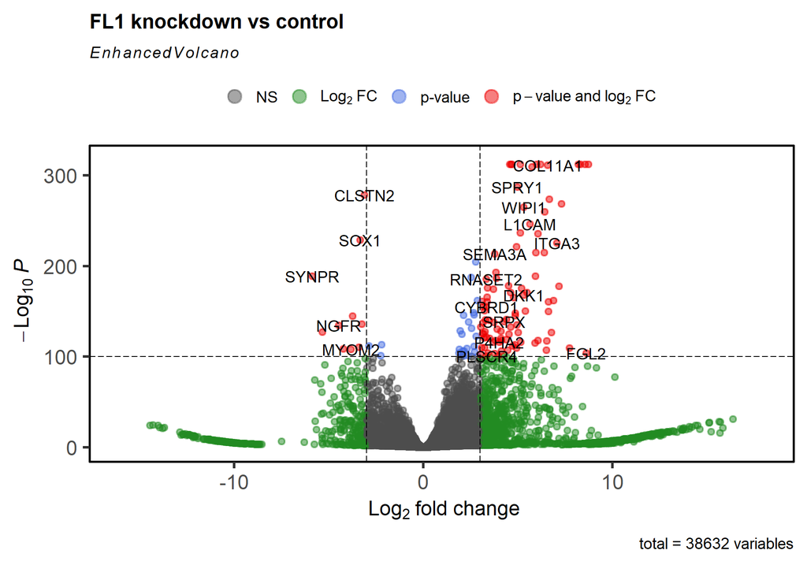

To identify high-confidence candidates, a stringent threshold of an adjusted p-value ($\text{P}_{\text{adj}}$) < 0.01 and an absolute log2 fold change |log2FC| > 1 was applied. Additionally, low-count genes were excluded, retaining only those with a minimum base mean of 20 across all samples. Notably, on the volcano plot, the ($\text{P}_{\text{adj}}$) threshold was adjusted to $\text{10}^{\text{-100}}$ to highlight extreme outliers.

### Heatmap of top 10 under- and overexpressed genes

The heatmap was generated to visualize the difference in expression levels of individual significant genes across all biological replicates.

For this visualization, a “head and tail” selection was applied to include the 10 most upregulated and 10 most downregulated significant genes and prevent the dominance of a single direction of change.

The values are row-scaled (Z-scores) to highlight relative expression differences rather than absolute count magnitudes.

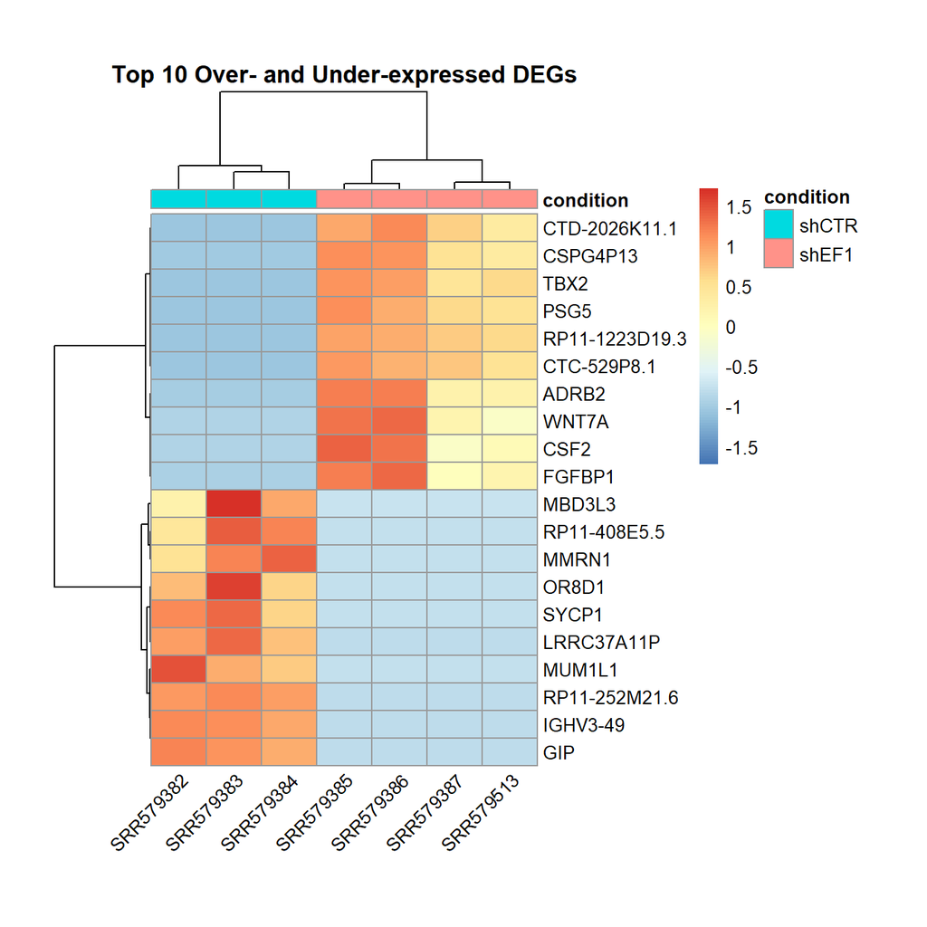

```r
# plot heatmap of top 20 DE genes but include over- and underexpressed
ordered_sig <- sig_res[order(sig_res$log2FoldChange, decreasing = TRUE), ]

# choose top10 overexpressed and top10 underexpressed
top_20_hm_degs <- rbind(head(ordered_sig, 10), tail(ordered_sig, 10))
mat_top <- assay(vsd)[top_20_hm_degs$GENEID, ]
rownames(mat_top) <- top_20_hm_degs$SYMBOL

pheatmap(mat_top,
  scale = "row",
  clustering_distance_rows = "correlation",
  annotation_col = as.data.frame(colData(vsd)[, "condition", drop = FALSE]),
  main = "Top 10 Over- and Under-expressed DEGs",
  cellwidth = 30,
  cellheight = 15,
  angle_col = "45"
)
```

### GSEA: Significantly enriched pathways

The primary objective of Gene Set Enrichment Analysis (GSEA) is to shift the focus from individual genes to coordinated biological pathways and processes. To perform this analysis, all detected genes were ranked by statistical significance and the direction of change. This ranked list was then compared against the KEGG database using the clusterProfiler package. This approach is particularly powerful as it can detect subtle but consistent shifts in functionally related genes that might not pass the stringent thresholds of individual gene analysis, providing a more robust biological interpretation of the EWSR1-FLI1 knockdown effect.

#### by NES (table)

```r
resdf2 <- resdf |>
  arrange(padj) |>
  mutate(gsea_metric = -log10(padj) * sign(log2FoldChange))

# Deal with inf
resdf2 <- resdf2 |>
  mutate(padj = case_when(
    padj == 0 ~ .Machine$double.xmin,
    TRUE ~ padj
  )) |>
  mutate(gsea_metric = -log10(padj) * sign(log2FoldChange))

# Remove NAs and order by GSEA
resdf2 <- resdf2 |>
  dplyr::filter(!is.na(gsea_metric)) |>
  arrange(desc(gsea_metric))

# Get the ranked GSEA vector
ranks <- resdf2 |>
  dplyr::select(SYMBOL, gsea_metric) |>
  distinct(SYMBOL, .keep_all = TRUE) |>
  deframe()

# Run GSEA
gene_sets <- msigdbr(
  species = "Homo sapiens",
  category = "C2",
  subcollection = "CP:KEGG_LEGACY"
) |>
  dplyr::select(gs_name, gene_symbol)
gseares <- GSEA(
  geneList = ranks,
  TERM2GENE = gene_sets,
  pvalueCutoff = 1,
  verbose = FALSE
)
gsearesdf <- as.data.frame(gseares)
# Get the 'top' table
gsea_top_table <- gsearesdf |>
  arrange(desc(NES)) |>
  slice(c(1:5, (n() - 4):n())) |>
  dplyr::select(ID, setSize, NES, p.adjust)

# Add description
gsea_top_table$Direction <- ifelse(gsea_top_table$NES > 0, "Activated", "Suppressed")

datatable(gsea_top_table,
  rownames = FALSE,
  caption = "Top enriched KEGG pathways by effect size (NES)",
  colnames = c("Pathway ID", "Size", "NES", "Adj. P-value", "Knockdown effect"),
  options = list(
    pageLength = 10,
    autoWidth = TRUE,
    scrollX = TRUE,
    columnDefs = list(list(className = "dt-left", targets = "_all"))
  )
) |>
  formatRound(columns = c("NES"), digits = 2) |>
  formatRound(columns = c("p.adjust"), digits = 4)
```

| Pathway ID | Size | NES | Adj. P-value | Knockdown effect |
| --- | --- | --- | --- | --- |
| KEGG_ECM_RECEPTOR_INTERACTION | 82 | 1.734115535438968 | 1.376555275584351e-06 | Activated |
| KEGG_HEMATOPOIETIC_CELL_LINEAGE | 62 | 1.631549014628915 | 0.002129185063970053 | Activated |
| KEGG_FOCAL_ADHESION | 196 | 1.591133934073054 | 0.0002330447759216068 | Activated |
| KEGG_JAK_STAT_SIGNALING_PATHWAY | 114 | 1.566573216933452 | 0.003020747643059852 | Activated |
| KEGG_CELL_ADHESION_MOLECULES_CAMS | 118 | 1.543932230584574 | 0.004303731715286599 | Activated |
| KEGG_DNA_REPLICATION | 36 | -1.615433251900452 | 0.0742160298839137 | Suppressed |
| KEGG_RNA_DEGRADATION | 54 | -1.706951136568175 | 0.03814716701279308 | Suppressed |
| KEGG_ALDOSTERONE_REGULATED_SODIUM_REABSORPTION | 38 | -1.711880264042172 | 0.04990886692532914 | Suppressed |
| KEGG_SPLICEOSOME | 127 | -1.866562349406114 | 0.0008159761679218703 | Suppressed |
| KEGG_RIBOSOME | 87 | -1.886570496062456 | 0.002238966881680357 | Suppressed |

#### by gene ratio (dotplot)

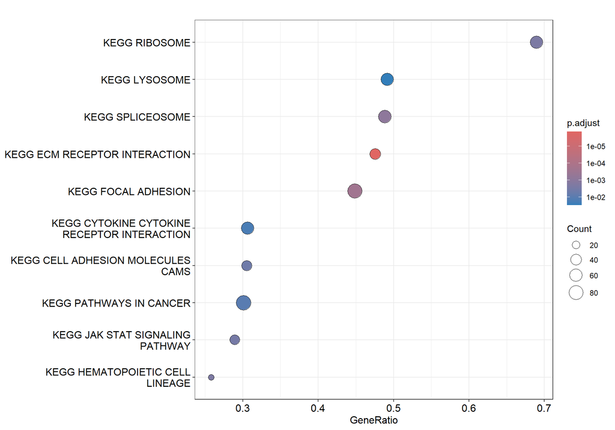

```r
dotplot(gseares)
```

The GSEA analysis results indicate that FL1-knockdown resulted in suppression of genes related to DNA-replication, RNA degradation, spliceosome and ribosome, which is probably a good sign and protects the cell from out of control division. On the other hand the processes involved in homeostasis, signaling (Jak-STAT signaling pathway), differentiation, proliferation (ECM Receptor interaction, focal adhesion), and cellular stages (hematopoietic cell lineage) are activated. Although the adjusted p-values for some pathways are relatively higher, their enrichment remains biologically consistent with the overall suppression of the oncogenic signature. The coordinated activation of cell adhesion and signaling pathways, coupled with the robust downregulation of the translational and replicative machinery clearly points toward the loss of the Ewing Sarcoma proliferative phenotype.

### Top activated and supressed pathways

#### Activated pathways

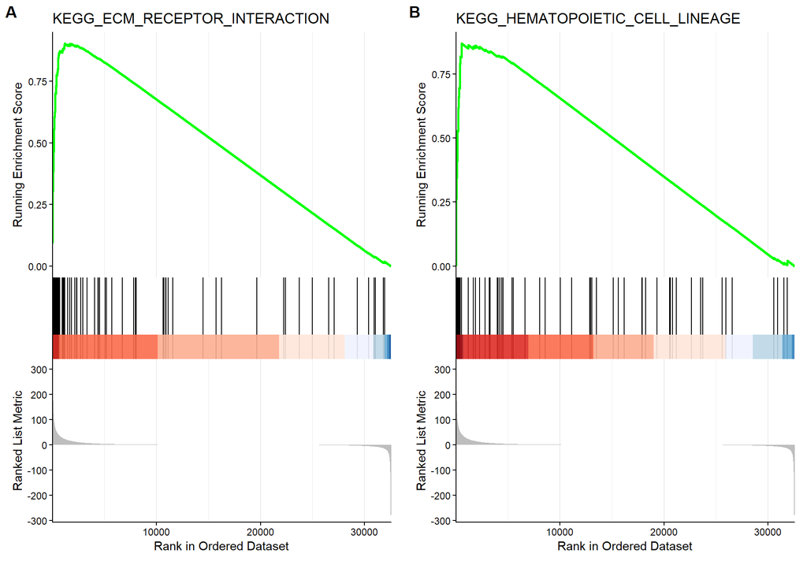

```r
top_pathways <- gsearesdf |>
  top_n(n = 2, wt = NES) |>
  pull(ID)
# Make gseaplot for each and return as list
top_pathway_plots <- lapply(
  top_pathways,
  function(pathway) {
    p1 <- gseaplot2(
      gseares,
      geneSetID = pathway,
      title = pathway,
      subplots = 1:3
    )
    as.ggplot(p1)
  }
)

# Arrange as a multi-panel plot
top_pathway_plot <- ggarrange(
  plotlist = top_pathway_plots,
  ncol = 2, nrow = 1, labels = "AUTO"
)
top_pathway_plot
```

#### Supressed pathways

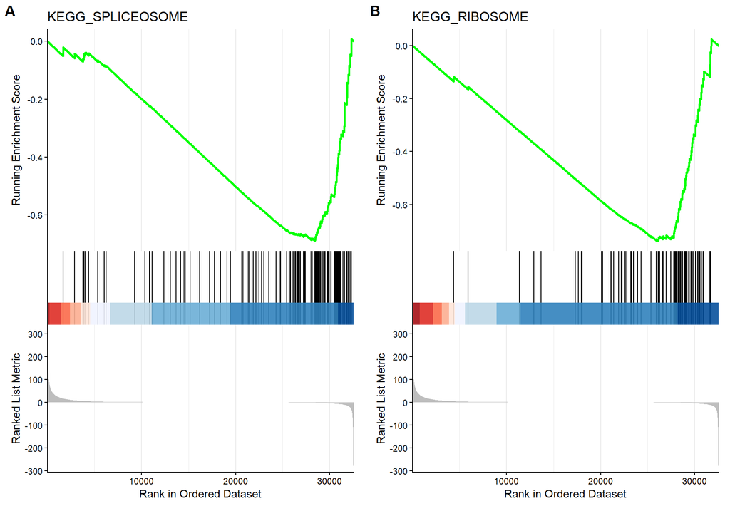

```r
bottom_pathways <- gsearesdf |>
  top_n(n = 2, wt = -NES) |>
  pull(ID)
bottom_pathway_plots <- lapply(
  bottom_pathways,
  function(pathway) {
    p2 <- gseaplot2(
      gseares,
      geneSetID = pathway,
      title = pathway,
      subplots = 1:3
    )
    as.ggplot(p2)
  }
)

bottom_pathway_plot <- ggarrange(
  plotlist = bottom_pathway_plots,
  ncol = 2, nrow = 1,
  labels = "AUTO"
)
bottom_pathway_plot
```

#### Overexpressed genes in suppressed pathways

```r
suppressed_pathways <- c(
  "KEGG_RIBOSOME", "KEGG_DNA_REPLICATION",
  "KEGG_RNA_DEGRADATION", "KEGG_SPLICEOSOME"
)

# See the top of upregulated genes within those clasters
all_outliers <- resdf2 |>
  filter(SYMBOL %in% (gene_sets |>
    filter(gs_name %in% suppressed_pathways) |>
    pull(gene_symbol))) |>
  # Specify the pathway name
  inner_join(gene_sets, by = c("SYMBOL" = "gene_symbol")) |>
  filter(gs_name %in% suppressed_pathways) |>
  group_by(gs_name) |>
  arrange(desc(gsea_metric)) |>
  slice_head(n = 10) |>
  select(gs_name, SYMBOL, log2FoldChange, padj, gsea_metric)

datatable(all_outliers,
  caption = "Top upregulated genes enriched within suppressed KEGG pathways ",
)
```

|  | gs_name | SYMBOL | log2FoldChange | padj | gsea_metric |
| --- | --- | --- | --- | --- | --- |
| 1 | KEGG_DNA_REPLICATION | POLD4 | 2.035248129996557 | 1.113793379974483e-34 | 33.9531953677437 |
| 2 | KEGG_DNA_REPLICATION | POLE4 | 0.09188558027727814 | 0.7050851515552704 | 0.1517584310689669 |
| 3 | KEGG_DNA_REPLICATION | PRIM2 | 0.06882249838732334 | 0.717969111012166 | 0.1438942398879739 |
| 4 | KEGG_DNA_REPLICATION | RPA4 | 0.1354363504730106 | 0.85314113090487 | 0.06897911970787572 |
| 5 | KEGG_DNA_REPLICATION | RPA1 | -0.184649702002005 | 0.2789730724437587 | -0.554437714480765 |
| 6 | KEGG_DNA_REPLICATION | RNASEH1 | -0.2450515864385807 | 0.1107392355013044 | -0.9556984790064134 |
| 7 | KEGG_DNA_REPLICATION | RPA3 | -0.5113612360668675 | 0.01698625430667837 | -1.769902378240163 |
| 8 | KEGG_DNA_REPLICATION | RNASEH2C | -0.2955971110418437 | 0.004192615749462671 | -2.377514938582581 |
| 9 | KEGG_DNA_REPLICATION | POLD2 | -0.2679511471235496 | 0.003414320499303946 | -2.466695714461449 |
| 10 | KEGG_DNA_REPLICATION | POLA2 | -0.4266094713025017 | 0.000150771538930089 | -3.821680632287063 |

[output cut: 30 more lines]

The Enrichment Score plots demonstrate a robust enrichment of activated pathways, while suppressed pathways (e.g., Ribosome, DNA Replication) exhibit a dominant trend of downregulation despite small subsets of atypical upregulated genes. These outliers typically fall into two categories: low-LFC metabolic genes with minimal impact on the overall enrichment score, or high-LFC stress-response proteins, such as the HSP70 family, indicating a robust cellular response to EwS-FLI1 depletion.A notable exception is POLD4, which is significantly upregulated within the otherwise suppressed DNA Replication pathway. Since POLD4 is frequently downregulated in malignant phenotypes to facilitate genomic instability, its dramatic reactivation suggests that EwS-FLI1 knockdown may trigger a shift toward more stable, non-oncogenic DNA replication fidelity.

### Conclusion

The differential expression analysis reveals a profound transcriptomic reprogramming of Ewing Sarcoma cells following EWSR1-FLI1 knockdown. The results demonstrate that the oncogenic phenotype is maintained through the coordinated upregulation of the cell’s replicative and translational machinery.

**Key biological shifts observed include:**